# bayesOmic: Association analysis of genomic data using a Bayesian shared component model

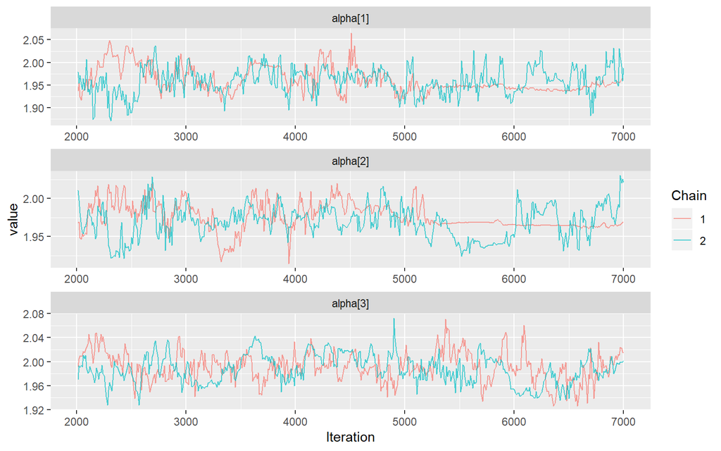

```r
checkConvergence(mod.CNV, type="trace")
```

The shared components are

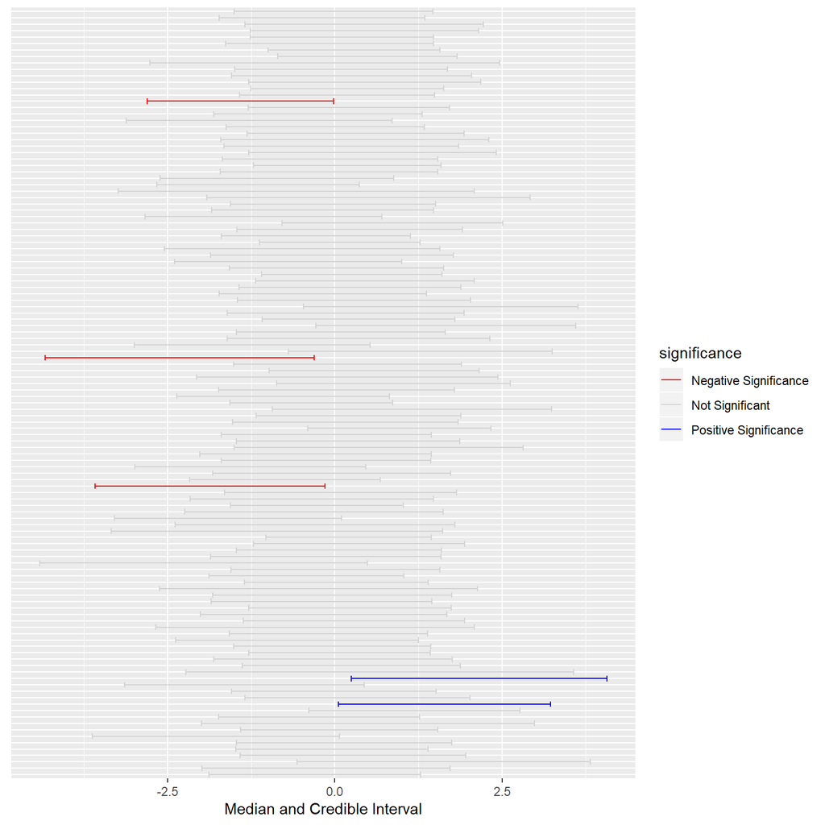

```r
plot(mod.CNV, type="shared")
```

The Specific components for each population can be obtained by typing:

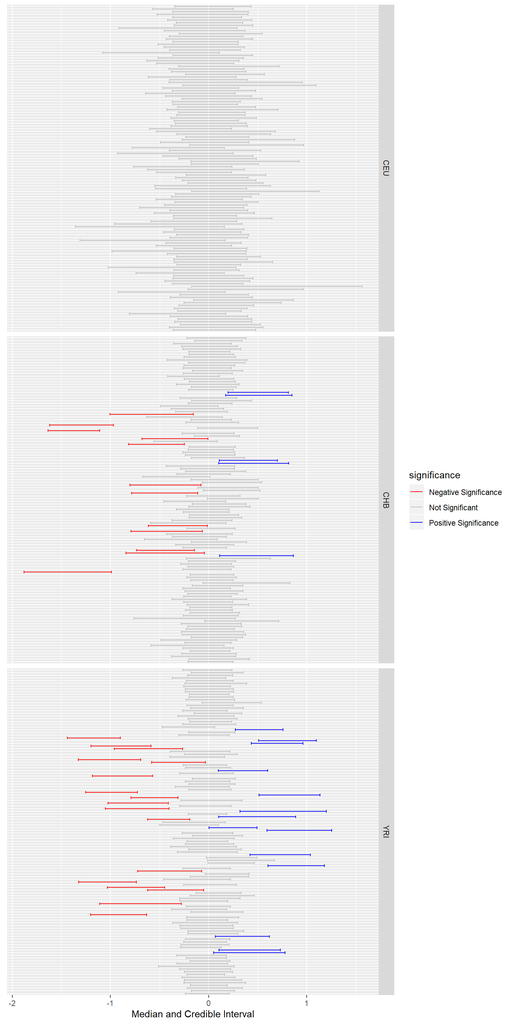

```r
plot(mod.CNV, type="specific")
```

We can obtain the name of the specific features of a given population by

```r
getSpecific(mod.CNV, group="YRI")
                          0.02083333%        50%   99.97917% sig
A_14_P133280               0.06763623  0.3923638  0.61740984   1
Chr22_22690592            -1.18536714 -0.9213787 -0.57026055  -1
Chr3_46771035             -1.32848491 -1.0507040 -0.69402418  -1
Chr3_164046699            -0.58112418 -0.3722404 -0.03203335  -1
Chr6_32594054             -1.44128167 -1.2551700 -0.90018456  -1
Chr7_141965669             0.27310133  0.5425233  0.75910157   1
Chr1_193470134            -1.20319975 -0.9561185 -0.63056296  -1
Chr1B_Pop_1                0.51405869  0.9056115  1.13324704   1
Chr13_Pop_2               -1.32564575 -1.0618913 -0.73629539  -1
Chr15_Pop_2               -0.72332912 -0.4086065 -0.07039649  -1
Chr1B_Pop_2               -1.25297915 -1.0430102 -0.72759685  -1
Chr22_Pop_2                0.09978223  0.3816358  0.60097198   1
Chr16_Pop_2                0.42150776  0.7498838  1.03766377   1
chr17_420_B               -0.62030713 -0.4731865 -0.19298312  -1
A_14_P127743               0.10664318  0.4460031  0.73170611   1
A_14_P126481               0.05223382  0.4640474  0.77803709   1
chr17_335_A                0.59355894  0.9151418  1.25427520   1
chr1_723_B                -1.11109569 -0.7066409 -0.27762726  -1
chr17_576_B               -1.02381512 -0.7523827 -0.40964742  -1
chr19_8743145_8784792_B   -0.79077440 -0.6296053 -0.31345325  -1
chr17_42973027_43038163_A -1.05409582 -0.7706621 -0.40530189  -1
chr5_150_A                -0.96083082 -0.6534143 -0.26341683  -1
chr5_150_B                -1.19852234 -0.9124652 -0.58677297  -1
chr12_111_A               -0.62160140 -0.4031858 -0.05218896  -1
chr12_111_B               -1.03174522 -0.7799813 -0.44949760  -1
chr16_543_A                0.60508802  0.9612111  1.18016961   1
chr17_415_A                0.00336770  0.2861445  0.49195291   1
chr5_704_A                 0.43596081  0.7652788  0.96254494   1
chr5_704_B                 0.51160610  0.8550052  1.09776158   1
chr17_429_A2               0.10071714  0.4496998  0.88546379   1
chr17_429_B2               0.32001998  0.7689257  1.19919063   1
```

The heatmap is obtained by:

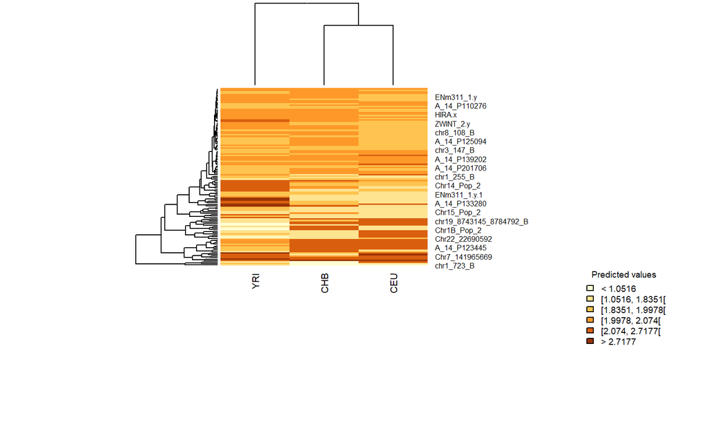

```r
makeHeatmap(mod.CNV, quantiles=c(.025, 0.2, 0.5, 0.8, 0.975))
```

# 6 Analysis of expression data (SummarizedExperiment objects)

Dataset can be loaded by typing:

```r
library(airway)
data(airway)
```

We can analyse a specific genomic range of interest (i.e. chromosome 1, positions 1 to 10000000). We define the `roi` by executing:

```r
library(GenomicRanges)
library(IRanges)
roi <- GRanges(seqnames = "1", ranges= IRanges(1,10000000))
```

Model parameter estimates are obtained using the function `bayesOmicAssoc` with the argument `roi` by executing:

```r
mod.Expr <- bayesOmicAssoc(group="dex", data=airway, roi = roi)
```

The intercept ans coefficient of shared components of populations can be obtained by:

```r
mod.Expr

 Intercepts (alpha):
                   2.5%      50%    97.5%
trt   57.84007 52.06141 56.52526 64.16210
untrt 61.21354 54.68929 60.43645 68.42294

 Coefficients of shared components (beta):
                    2.5%      50%    97.5%
trt   22.48862 -1170.707 22.51068 1216.708
untrt 23.23461 -1141.757 23.41146 1188.526

 Use 'getSpecific()' and 'getShared()' functions to get specific or shared components, respectively.
```

We can check model convergence by

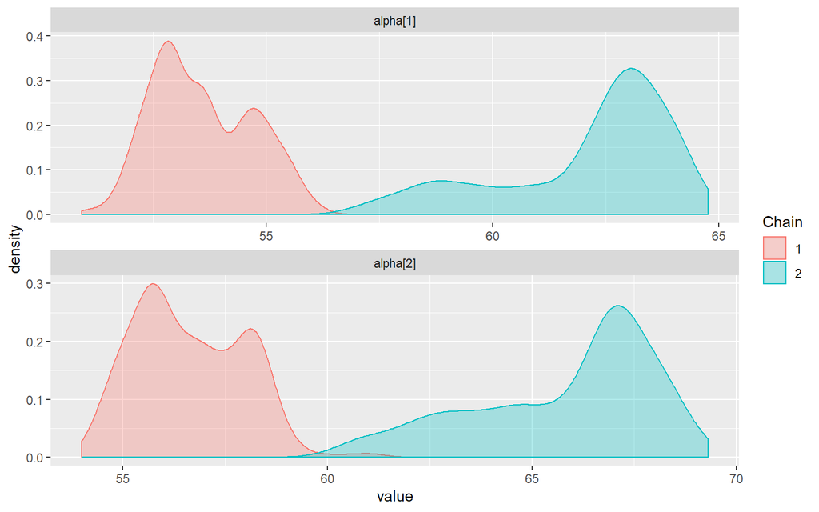

```r
checkConvergence(mod.Expr)
```

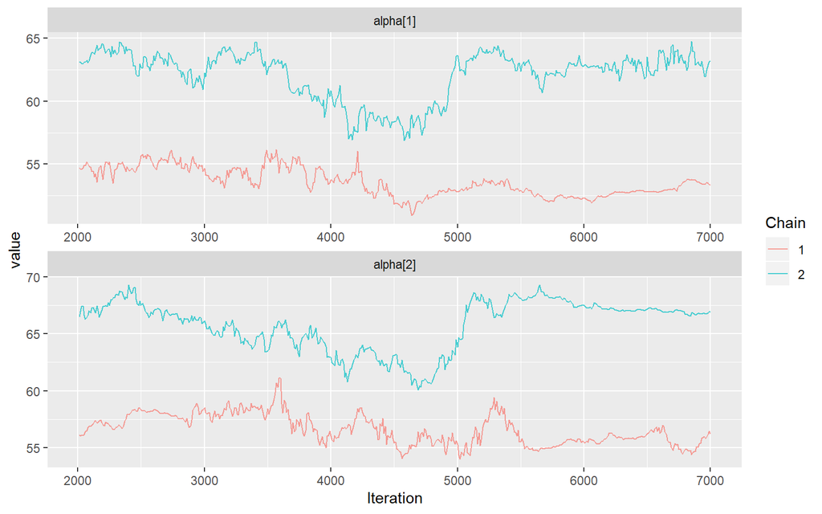

```r
checkConvergence(mod.Expr, type="trace")
```

The shared components are

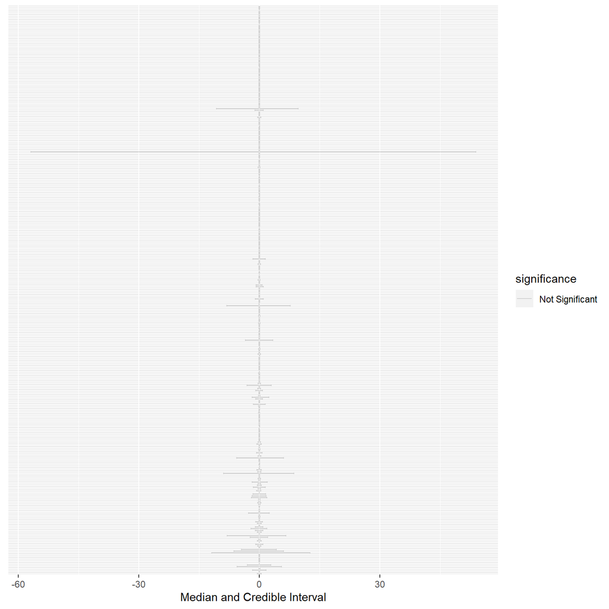

```r
plot(mod.Expr, type="shared")
```

The Specific components for each population can be obtained by typing:

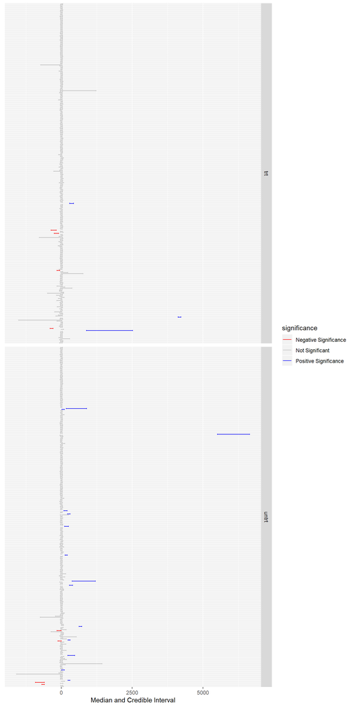

```r
plot(mod.Expr, type="specific")
```

We can obtain the name of the specific features of a given population by

```r
getSpecific(mod.Expr, group="trt")
                0.007598784%       50%   99.9924% sig
ENSG00000074800     885.9314 1721.7064 2517.94808   1
ENSG00000078808    -397.6550 -345.6475 -298.96838  -1
ENSG00000116285    4124.1588 4175.5141 4216.24430   1
ENSG00000171621    -159.6921 -112.5400  -61.63555  -1
ENSG00000197530    -256.9448 -214.8600  -99.94193  -1
ENSG00000198744    -370.6941 -331.0370 -182.63530  -1
ENSG00000221978     286.5767  336.8142  425.34197   1
```

The heatmap is obtained by:

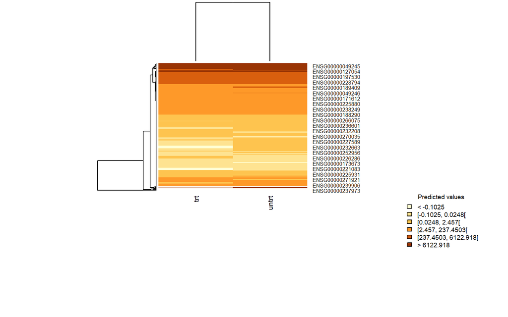

```r
makeHeatmap(mod.Expr, quantiles=c(.025, 0.2, 0.5, 0.8, 0.975))
```

# 7 Acknowledgments

# References

Abellan, Juan J, Carlos Abellan, and Juan R Gonzalez. 2010. “A Bayesian Shared Component Model for Genetic Association Studies.”

González, Juan R, Carlos Abellán, and Juan J Abellán. 2012. “Bayesian Model to Detect Phenotype-Specific Genes for Copy Number Data.” *BMC Bioinformatics* 13 (1): 130.

Plummer, Martyn, and others. 2003. “JAGS: A Program for Analysis of Bayesian Graphical Models Using Gibbs Sampling.” In *Proceedings of the 3rd International Workshop on Distributed Statistical Computing*, 124:10. 125. Vienna, Austria.